# Data Visualization Using ggplot2

Jake Thompson

October 10, 2016

## What is ggplot2?

ggplot2 is a data visualization package written by [Hadley Wickham](http://www.twitter.com/hadleywickham) that uses the “grammar of graphics.” The grammar of graphics provides a consistent way to describe the components of graph, allowing us to move beyond specific types of plots (e.g., boxplot, scatterplot, etc.) to different elements that compose the plot. As the name would imply, the grammar of graphics is a language we can use to describe and build visualizations.

Today we’ll be using data on US breweries (yay beer!) to explore some of ggplot2’s capabilities. First, we will install the packages we will need.

```r
# install.packages("devtools")
# devtools::install_github("hadley/ggplot2")
# devtools::install_github("hadley/dplyr")
# devtools::install_github("hadley/purrr")
# devtools::install_github("hadley/tidyr")
# devtools::install_github("hadley/forcats")
# devtools::install_github("hadley/readr")
# devtools::install_github("dgrtwo/gganimate")
# install.packages("maps")
library(ggplot2)
library(dplyr)
library(purrr)
library(tidyr)
library(forcats)
library(readr)
library(gganimate)
library(maps)
```

## The dataset

The dataset contains the information on breweries across the United States scraped from [beer advocate](https://www.beeradvocate.com/). Information on the breweries includes the brewery name, brewery rating, the number of reviews, the average rating of their beers, the number of beers they serve, and location information.

```r
all_breweries <- read_csv("all_breweries.csv", col_types = "cnnnnccccnncnn")
all_breweries
```

| brewery_name | brewery_rating | num_reviews | beer_avg | num_beers | address | type | city | state | lon | lat | full_city | city_lon | city_lat |
| --- | --- | --- | --- | --- | --- | --- | --- | --- | --- | --- | --- | --- | --- |
| 603 Brewery | NA | NA | 3.75 | 20 | 12 Liberty Dr Unit 7 Londonderry, New Hampshire, 03053-2286 United States | Brewery | Londonderry | New Hampshire | -71.36299 | 42.91614 | Londonderry, New Hampshire | -71.37393 | 42.86513 |
| 7th Settlement Brewery | 4.23 | 24 | 3.61 | 41 | 47 Washington St Dover, New Hampshire, 03820-3877 United States | Brewery, Bar, Eatery | Dover | New Hampshire | -70.87360 | 43.19516 | Dover, New Hampshire | -70.87367 | 43.19786 |
| Agner & Wolf Brewery Corp. | NA | NA | 3.61 | 4 | 4 Bud Way Ste 16 Nashua, New Hampshire, 03063-1740 United States | Brewery | Nashua | New Hampshire | -71.50191 | 42.77600 | Nashua, New Hampshire | -71.46757 | 42.76537 |
| Ashuelot Brewing Company | NA | NA | NA | 0 | 101 Old County Rd Richmond, New Hampshire, 03470 United States | Brewery | Richmond | New Hampshire | -72.23375 | 42.75957 | Richmond, New Hampshire | -72.27159 | 42.75447 |
| Bad Lab Beer Co. | NA | NA | NA | 4 | 460 High St Somersworth, New Hampshire, 03878-1012 United States | Brewery | Somersworth | New Hampshire | -70.88176 | 43.23040 | Somersworth, New Hampshire | -70.86534 | 43.26175 |
| Beara Irish Brewing Co. | 4.12 | 5 | 3.60 | 22 | 2800 Lafayette Rd Portsmouth, New Hampshire, 03801-5915 United States | Brewery, Bar, Eatery | Portsmouth | New Hampshire | -70.79007 | 43.02919 | Portsmouth, New Hampshire | -70.76255 | 43.07176 |
| Belgian Mare Brewery | NA | NA | 3.39 | 7 | 207 Gilsum Mine Rd East Alstead, New Hampshire, 03602-3915 United States | Brewery | East Alstead | New Hampshire | -72.28561 | 43.11241 | East Alstead, New Hampshire | -72.27898 | 43.12397 |
| Big Water Brewery | NA | NA | 3.17 | 8 | 24 Robie Rd Salisbury, New Hampshire, 03268-5423 United States | Brewery | Salisbury | New Hampshire | -71.71700 | 43.40920 | Salisbury, New Hampshire | -71.71702 | 43.38008 |
| Blackstone Brewing Company | NA | NA | NA | 4 | 7 Austin Rd Amherst, New Hampshire, 03031 United States | Brewery | Amherst | New Hampshire | -71.60705 | 42.89641 | Amherst, New Hampshire | -71.62535 | 42.86147 |
| Border Brew Supply | 3.85 | 10 | 3.39 | 11 | 224 N Boradway Salem, New Hampshire, 03079-2145 United States | Brewery, Bar | Salem | New Hampshire | -71.23383 | 42.78961 | Salem, New Hampshire | -71.20089 | 42.78856 |

[output cut: 990 more lines]

## Making a plot

Let’s look at the relationship between the brewery’s overall rating and the number of beers they serve.

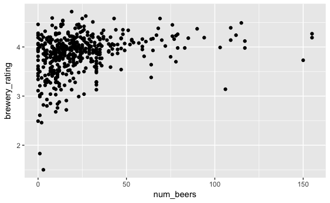

```r
brew_plot <- all_breweries %>%
  filter(!is.na(brewery_rating), !is.na(num_beers),
    state %in% c("Kansas", "Oklahoma", "Missouri", "Missouri", "Iowa",
      "Nebraska", "Colorado"),
    num_beers < 400)
ggplot(data = brew_plot) +
  geom_point(mapping = aes(x = num_beers, y = brewery_rating))
```

`ggplot()` initializes a blank plot, and then layers (geoms) are added to complete the plot. For example, `geom_point()` adds points to create a scatterplot. In the geom call, the user specifies which variable map to the x- and y-axes. We can create a general form all ggplot2 graphics:

```r
ggplot(data = <DATA>) +
  <GEOM_FUNCTION>(mapping = aes(<MAPPINGS>))
```

## Aesthetic mappings

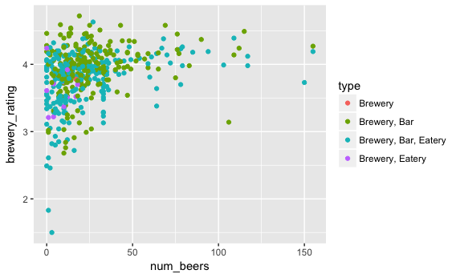

```r
ggplot(data = brew_plot) +
  geom_point(mapping = aes(x = num_beers, y = brewery_rating, color = type))
```

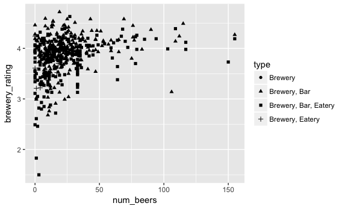

```r
ggplot(data = brew_plot) +
  geom_point(mapping = aes(x = num_beers, y = brewery_rating, shape = type))
```

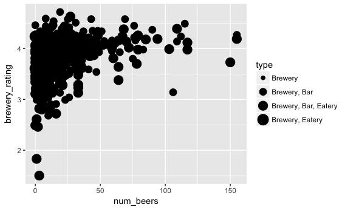

```r
ggplot(data = brew_plot) +
  geom_point(mapping = aes(x = num_beers, y = brewery_rating, size = type))
```

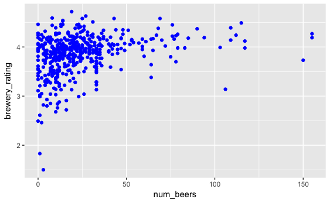

```r
ggplot(data = brew_plot) +
  geom_point(mapping = aes(x = num_beers, y = brewery_rating), color = "blue")
```

Inside of the `aes()` command, ggplot2 maps the aesthetic to a variable in your dataset and creates a legend. Outside of the `aes()` command, aesthetics can be fixed to a specific value. For a list of aesthetics that each geom can use, see the help page (e.g., `?geom_point`).

## Common geoms

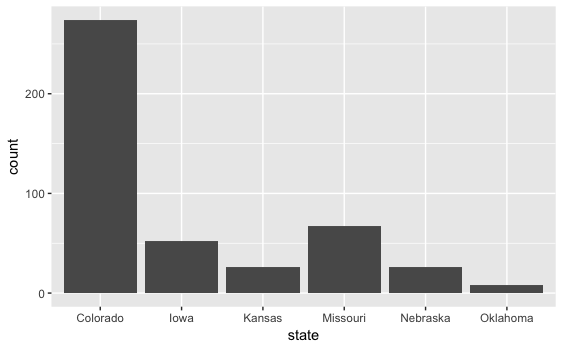

```r
ggplot(data = brew_plot) +
  geom_bar(mapping = aes(x = state))
```

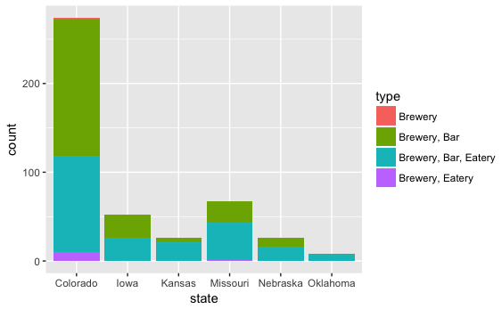

```r
ggplot(data = brew_plot) +
  geom_bar(mapping = aes(x = state, fill = type))
```

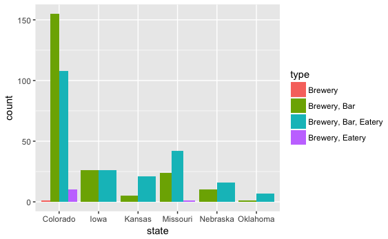

```r
ggplot(data = brew_plot) +
  geom_bar(mapping = aes(x = state, fill = type), position = position_dodge())
```

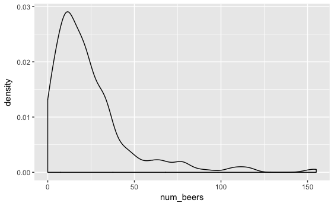

```r
ggplot(data = brew_plot) +
  geom_density(mapping = aes(x = num_beers))
```

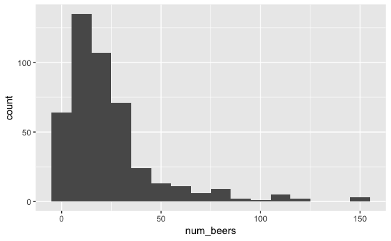

```r
ggplot(data = brew_plot) +
  geom_histogram(mapping = aes(x = num_beers), binwidth = 10)
```

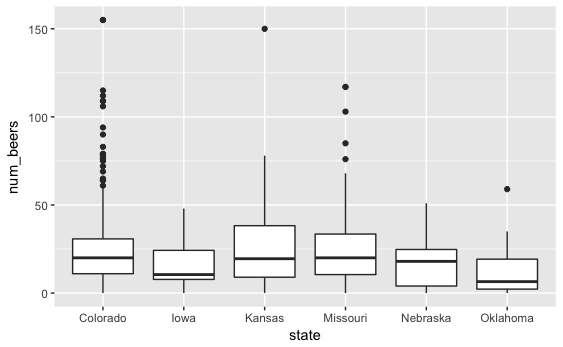

```r
ggplot(data = brew_plot) +
  geom_boxplot(mapping = aes(x = state, y = num_beers))
```

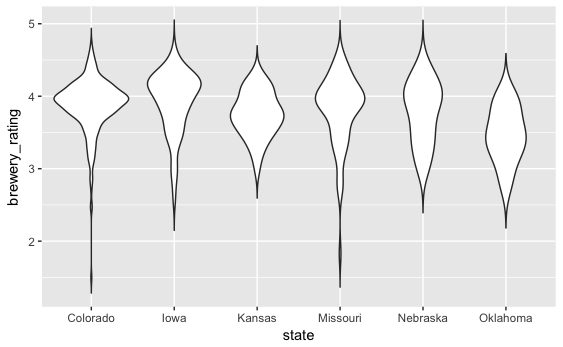

```r
ggplot(data = brew_plot) +
  geom_violin(mapping = aes(x = state, y = brewery_rating))
```

## Layering geoms

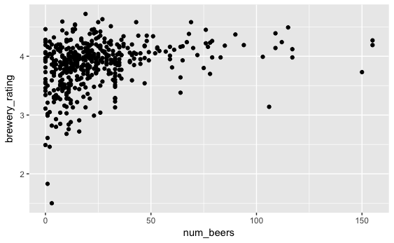

```r
ggplot(data = brew_plot) +
  geom_point(mapping = aes(x = num_beers, y = brewery_rating))
```

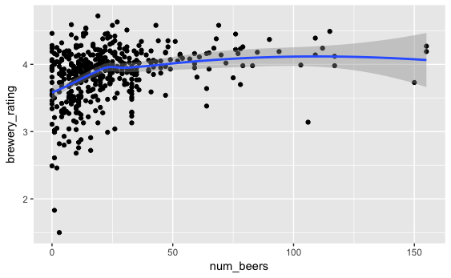

```r
ggplot(data = brew_plot) +
  geom_point(mapping = aes(x = num_beers, y = brewery_rating)) +
  geom_smooth(mapping = aes(x = num_beers, y = brewery_rating))
```

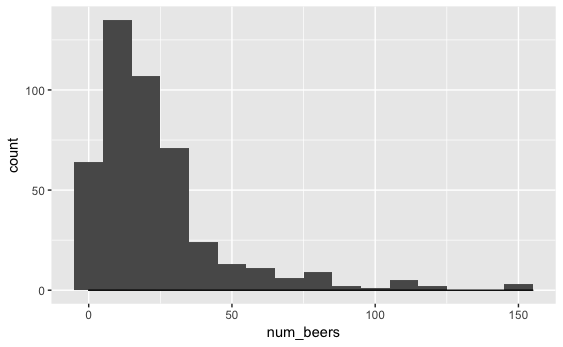

```r
ggplot(data = brew_plot) +
  geom_histogram(mapping = aes(x = num_beers), binwidth = 10) +
  geom_density(mapping = aes(x = num_beers), alpha = 0.4, fill = "red")
```

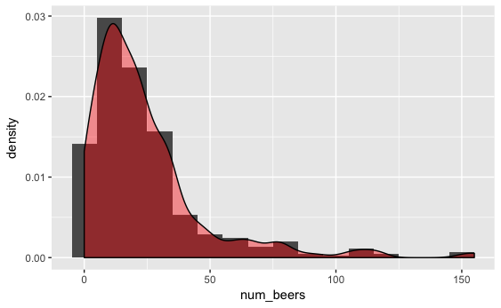

```r
ggplot(data = brew_plot) +
  geom_histogram(mapping = aes(x = num_beers, y = ..density..), binwidth = 10) +
  geom_density(mapping = aes(x = num_beers), alpha = 0.4, fill = "red")
```

Mapping in every geom can start to get redundant, so instead we can set global mappings.

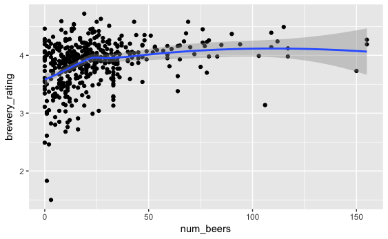

```r
ggplot(data = brew_plot, mapping = aes(x = num_beers, y = brewery_rating)) +
  geom_point() +
  geom_smooth()
```

You can also set local mappings that only apply to a specific layer.

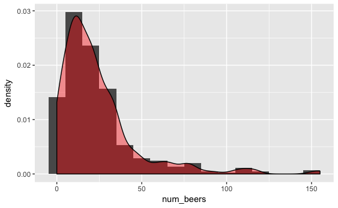

```r
ggplot(data = brew_plot, mapping = aes(x = num_beers)) +
  geom_histogram(mapping = aes(y = ..density..), binwidth = 10) +
  geom_density(alpha = 0.4, fill = "red")
```

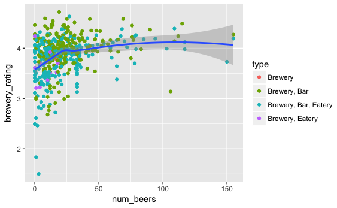

```r
ggplot(data = brew_plot, mapping = aes(x = num_beers, y = brewery_rating)) +
  geom_point(mapping = aes(color = type)) +
  geom_smooth()
```

We can similarly define which data should be used for a single geom.

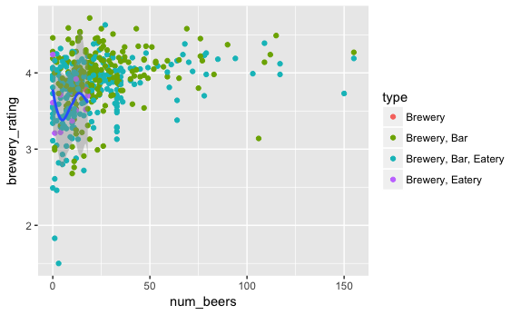

```r
ggplot(data = brew_plot, mapping = aes(x = num_beers, y = brewery_rating)) +
  geom_point(mapping = aes(color = type)) +
  geom_smooth(data = filter(brew_plot, type == "Brewery, Eatery"))
```

We can also show each subset individually using `facet_wrap()`.

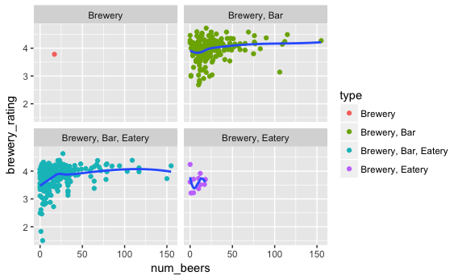

```r
ggplot(data = brew_plot, mapping = aes(x = num_beers, y = brewery_rating)) +
  geom_point(mapping = aes(color = type)) +
  geom_smooth(se = FALSE) +
  facet_wrap(~ type)
```

## Formatting ggplot2

**Anything** you see in a ggplot2 visualization can be altered. Most of this will occur through the `theme()` function, but labels occur in `scale_` or `labs`. There is [extensive documentation](http://docs.ggplot2.org/current/) on what all can be altered. And chances are if there is something you want to change, someone has had the same question, and [asked it online](http://stackoverflow.com/questions/tagged/ggplot2).

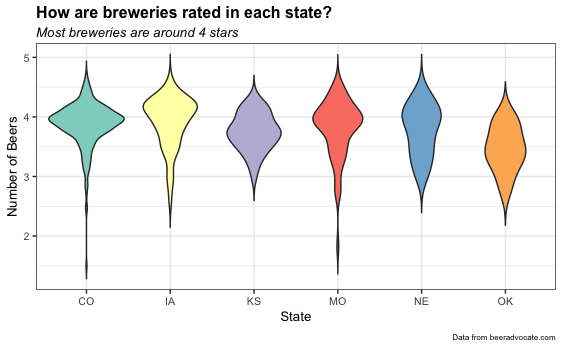

```r
ggplot(brew_plot) +
  geom_violin(mapping = aes(x = state, y = brewery_rating, fill = state)) +
  scale_x_discrete(labels = c("CO", "IA", "KS", "MO", "NE", "OK")) +
  scale_fill_brewer(type = "qual", palette = "Set3") +
  labs(x = "State", y = "Number of Beers",
    title = "How are breweries rated in each state?",
    subtitle = "Most breweries are around 4 stars",
    caption = "Data from beeradvocate.com") +
  theme_bw() +
  theme(plot.title = element_text(size = 12, face = "bold"),
        plot.subtitle = element_text(size = 10, face = "italic"),
        plot.caption = element_text(size = 6),
        axis.text = element_text(size = 8),
        axis.title = element_text(size = 10),
        axis.title.x = element_text(margin = margin(5, 0, 5, 0)),
        axis.title.y = element_text(margin = margin(0, 5, 0, 0)),
        legend.position = "none")
```

## Saving graphics

We can also save plots using the `ggsave` function. By default this saves the last plot you created.

```r
ggsave("Saved Images/Violin_Plot.png")
```

However you can also save your plots like you variable values and save them later.

```r
p <- ggplot(data = brew_plot, mapping = aes(x = num_beers)) +
    geom_histogram(mapping = aes(y = ..density..), binwidth = 10,
    alpha = 0.6, color = "black", fill = "black") +
  geom_density(fill = "red", color = "black", alpha = 0.3) +
    labs(x = "Number of Beers", y = "Density",
      title = "Distribution of Number of Beers Sold",
      subtitle = paste0("All Breweries"),
      caption = "Data from beeradvocate.com") +
    theme_bw() +
    theme(plot.title = element_text(size = 12, face = "bold"),
        plot.subtitle = element_text(size = 10, face = "italic"),
        plot.caption = element_text(size = 6),
        axis.text = element_text(size = 8),
        axis.title = element_text(size = 10),
        axis.title.x = element_text(margin = margin(5, 0, 5, 0)),
        axis.title.y = element_text(margin = margin(0, 5, 0, 0)),
        legend.position = "none")
ggsave("Saved Images/All_States.png", plot = p)
```

This can work in conjunction with other packages from the [tidyverse](https://blog.rstudio.org/2016/09/15/tidyverse-1-0-0/), such as `purrr`. Here we make the same plot as above, except for each state individually. We can save each of these plots in a list, and then use `pwalk` to save them all at once.

```r
plot_list <- unique(brew_plot$state) %>% list_along()
names(plot_list) <- unique(brew_plot$state)
for (i in seq_along(plot_list)) {
  plot <- ggplot(data = filter(brew_plot, state == names(plot_list)[i]),
                 mapping = aes(x = num_beers)) +
    geom_histogram(mapping = aes(y = ..density..), binwidth = 10,
    alpha = 0.6, color = "black", fill = "black") +
  geom_density(fill = "red", color = "black", alpha = 0.3) +
    labs(x = "Number of Beers", y = "Density",
      title = "Distribution of Number of Beers Sold",
      subtitle = paste0("Breweries in ", names(plot_list)[i]),
      caption = "Data from beeradvocate.com") +
    theme_bw() +
    theme(plot.title = element_text(size = 12, face = "bold"),
        plot.subtitle = element_text(size = 10, face = "italic"),
        plot.caption = element_text(size = 6),
        axis.text = element_text(size = 8),
        axis.title = element_text(size = 10),
        axis.title.x = element_text(margin = margin(5, 0, 5, 0)),
        axis.title.y = element_text(margin = margin(0, 5, 0, 0)),
        legend.position = "none")

  plot_list[[i]] <- plot
}
filenames <- paste0(names(plot_list), ".png")
pwalk(list(filenames, plot_list), ggsave,
      path = paste0(getwd(), "/Saved Images/"))
```

## Endless possibilities

Because geoms are layered, you aren’t limited to certain types of pre-defined visualizations (e.g., scatterplots, barplots, etc.). You can continue to add layers to communicate information (or to increase aesthetic appeal).

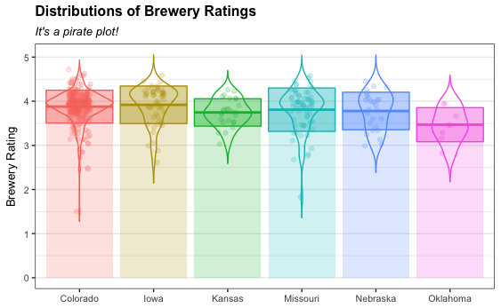

You also aren’t limited to the normal coordinate system. For example, you can map geospatial locations.

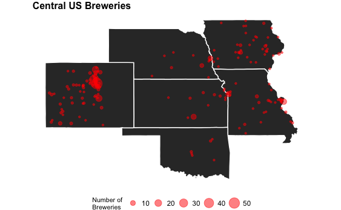

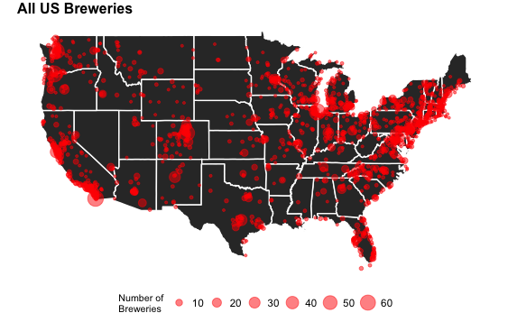

ggplot2 also has a strong online community of contributers that have written packages to [extend the capabilities](http://www.ggplot2-exts.org/gallery/) of ggplot2. For example, the `gganimate` package allows you to make animated visualizations.

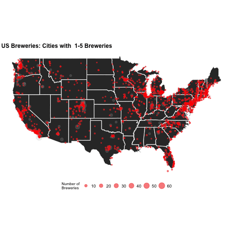

```r
brew_loc$brew_descrip <- case_when(
  brew_loc$num_brewery %in% 1:5 ~ "1-5 Breweries",
  brew_loc$num_brewery %in% 6:10 ~ "6-10 Breweries",
  brew_loc$num_brewery %in% 10:20 ~ "10-20 Breweries",
  brew_loc$num_brewery %in% 20:40 ~ "20-40 Breweries",
  brew_loc$num_brewery > 40 ~ "More than 40 Breweries"
)
brew_loc$brew_descrip <- fct_inorder(brew_loc$brew_descrip) %>% fct_rev()
p <- ggplot(data = brew_loc, mapping = aes(x = city_lon, y = city_lat,
    size = num_brewery, frame = brew_descrip)) +
  geom_polygon(data = states, mapping = aes(x = long, y = lat, group = group),
    color = "white", inherit.aes = FALSE) +
  geom_point(aes(x = city_lon, y = city_lat, size = num_brewery),
    color = "grey", alpha = 0.2, inherit.aes = FALSE) +
  geom_point(color = "red", alpha = 0.5) +
  scale_size_area(name = "Number of\nBreweries", breaks = seq(10, 60, 10)) +
  coord_map() +
  labs(title = "US Breweries: Cities with ") +
  theme_void() +
  theme(plot.title = element_text(size = 12, face = "bold",
                                  margin = margin(3, 0, 0, 0)),
        legend.position = "bottom",
        legend.title = element_text(size = 8),
        plot.margin = unit(c(0,0,0,0), "in")) +
  guides(size = guide_legend(nrow = 1))
gg_animate(p, interval = 2)
```

## Other Resources

- [Everything ggplot2](http://docs.ggplot2.org/current/)
- [ggplot2: Elegant graphics for data analysis](https://github.com/hadley/ggplot2-book) (Hadley Wickham)
- [R for Data Science: Data Visualization](http://r4ds.had.co.nz/data-visualisation.html) (Hadley Wickham & Garrett Grolemund)
- [ggplot2 extensions](http://www.ggplot2-exts.org/gallery/)
- ggplot2 vs. base graphics
  - [Use base graphics!](http://simplystatistics.org/2016/02/11/why-i-dont-use-ggplot2/) (Jeff Leek)
  - [Use ggplot2!](http://varianceexplained.org/r/why-I-use-ggplot2/) (David Robinson)
  - [Comparing ggplot2 and base graphics](http://flowingdata.com/2016/03/22/comparing-ggplot2-and-r-base-graphics/) (Nathan Yau)

```
 setting  value
 version  R version 3.3.1 (2016-06-21)
 system   x86_64, darwin13.4.0
 ui       RStudio (1.0.34)
 language (EN)
 collate  en_US.UTF-8
 tz       America/Chicago
 date     2016-10-10
```

```
Packages ------------------------------------------------------------------
```

```
 package      * version    date       source
 animation    * 2.4        2015-08-16 cran (@2.4)
 assertthat     0.1        2013-12-06 CRAN (R 3.3.0)
 base64enc      0.1-3      2015-07-28 cran (@0.1-3)
 colorspace     1.2-6      2015-03-11 CRAN (R 3.3.0)
 DBI            0.5-1      2016-09-10 cran (@0.5-1)
 devtools       1.12.0     2016-06-24 CRAN (R 3.3.0)
 digest         0.6.10     2016-08-02 cran (@0.6.10)
 dplyr        * 0.5.0.9000 2016-09-29 Github (hadley/dplyr@546a089)
 forcats      * 0.1.1.9000 2016-09-29 Github (hadley/forcats@5d469c1)
 formatR        1.4        2016-05-09 cran (@1.4)
 gganimate    * 0.1        2016-09-22 Github (dgrtwo/gganimate@26ec501)
 ggplot2      * 2.1.0.9001 2016-10-05 Github (hadley/ggplot2@3b29891)
 gtable         0.2.0      2016-02-26 CRAN (R 3.3.0)
 htmltools      0.3.5      2016-03-21 cran (@0.3.5)
 knitr        * 1.14       2016-08-13 CRAN (R 3.3.0)
 labeling       0.3        2014-08-23 CRAN (R 3.3.0)
 lazyeval       0.2.0.9000 2016-09-19 Github (hadley/lazyeval@c155c3d)
 magrittr       1.5        2014-11-22 CRAN (R 3.3.0)
 mapproj        1.2-4      2015-08-03 cran (@1.2-4)
 maps         * 3.1.1      2016-07-27 CRAN (R 3.3.0)
 memoise        1.0.0      2016-01-29 CRAN (R 3.3.0)
 munsell        0.4.3      2016-02-13 CRAN (R 3.3.0)
 plyr           1.8.4      2016-06-08 CRAN (R 3.3.0)
 purrr        * 0.2.2.9000 2016-09-26 Github (hadley/purrr@8c72c35)
 R6             2.1.3      2016-08-19 cran (@2.1.3)
 RColorBrewer   1.1-2      2014-12-07 CRAN (R 3.3.0)
 Rcpp           0.12.7     2016-09-05 cran (@0.12.7)
 readr        * 1.0.0.9000 2016-09-17 Github (hadley/readr@37d6eda)
 scales         0.4.0.9002 2016-10-05 Github (hadley/scales@38f81a7)
 stringi        1.1.2      2016-10-01 CRAN (R 3.3.1)
 stringr        1.1.0      2016-08-19 cran (@1.1.0)
 tibble         1.2-12     2016-10-05 Github (hadley/tibble@090e075)
 tidyr        * 0.6.0.9000 2016-09-17 Github (hadley/tidyr@3c9335b)
 withr          1.0.2      2016-06-20 CRAN (R 3.3.0)
```